# 群馬県 (議員定数：5 → 5)

アルゴリズムによる衆議院小選挙区の区割り改定案

ALARM Japan プロジェクトチーム  
July 18, 2022

**群馬県**

人口： 1,885,678 人（2020年）

|  | 現行 | 新たな区割り | アルゴリズムの提案 市区町村の分割無し | アルゴリズムの提案 最大市区町村の分割可 |
| --- | --- | --- | --- | --- |
| **1票の格差** |  |  |  |  |
| 県内較差 | 1.261 | 1.155 | 2.352 | 1.056 |
| 改善率 | - | 40.6% | −418.0% | 78.7% |
| **選挙区の状況** |  |  |  |  |
| 選挙区数 | 5 | 5 | 5 | 5 |
| 市区町村の分割 | 5<sup>a</sup> | 1<sup>b</sup> | 0 | 1<sup>b</sup> |
| 郡の分割 | 0 | 0 | 0 | 0 |
| 広域連携地域の分割 | 0 | 0 | 0 | 1<sup>c</sup> |

<sup>a</sup> 高崎市、桐生市、太田市、 渋川市、みどり市  
<sup>b</sup> 高崎市  
<sup>c</sup> 利根沼田地域定住自立圏

# 現行の区割り

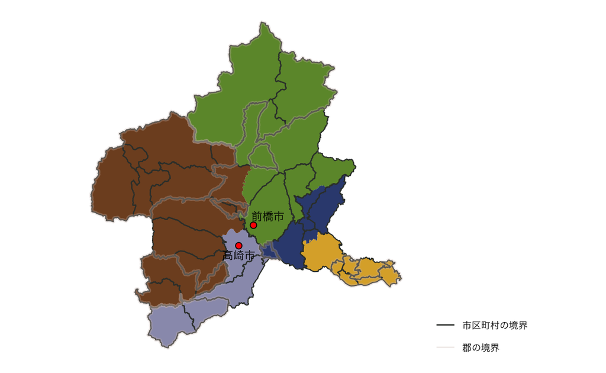

# アルゴリズムの提案

アルゴリズムが提案した5,000案のうち、一票の格差が最小のもの

注: 市区町村を分割しないシミュレーション結果の区割り案の多様性 (`plan diversity`)が、ソフトウェアが設定する理想値より低い。

### 市区町村を分割しない区割り案

一票の格差 : 2.352

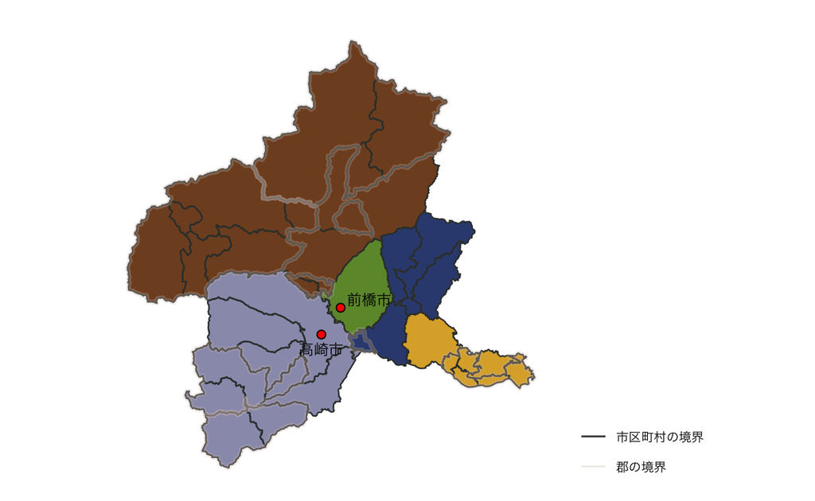

### 最大市区町村の分割を許容する区割り案

人口が最大の市区町村 : 高崎市

一票の格差 : 1.056

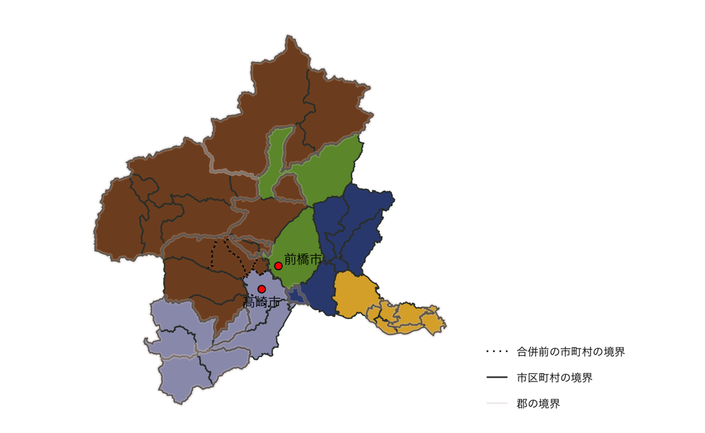

# 共起分析

- アルゴリズム設定
  - 市区町村の分割無し
  - 飛び地を含む案を棄却
  - 一票の格差が下位10％の案を抽出
- 読み取り方  
  地図上の市区町村の色が
  - 同じ → 同じ選挙区に属する傾向が強い
  - 同じ かつ 濃い → 隣接する市区町村と同じ選挙区に属する傾向が強い

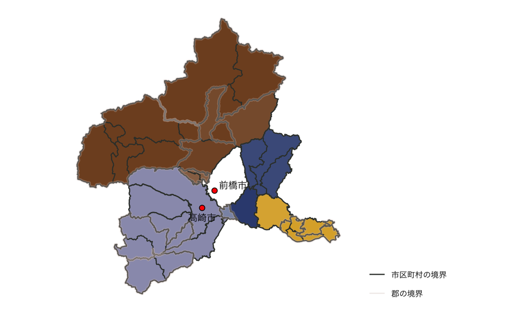

# アルゴリズム設定

- 各選挙区の人口 : (県内の日本人人口 / 選挙区数)
  - ± 50% (市区町村分割を許容しない案)
  - ± 30% (最大市区町村を分割する案)
  - サンプリング効率が80%~100%となるように調節
- 市区町村分割を許容しない案、及び日本人人口が最大の市（政令指定都市の行政区を除く）の分割を許容する案の2種類を作成
  - 最大市区町村を分割する際は、平成の大合併以前の市区町村界に基づく
  - 旧市区町村単位の人口（総人口-外国人人口）は、合併後の市区町村の人口（総人口-外国人人口）と旧市区町村単位の日本人人口を元に推計
- 郡の分割は、現行の区割りにて分割されている場合のみ許容
- 離島は、航路で結ばれている本土の市区町村と同一の選挙区にする
- 逐次モンテカルロ法(SMC)による4つの独立したシミュレーションにより、市区町村分割を許容しない案、最大市区町村の分割を許容する案をそれぞれ20,000作成
- 以下の案を棄却し有効な案を選定
  - 飛び地が生じる案
  - 市区町村が3つ以上の選挙区に分割される案
  - 市区町村の分割が現状よりも多い案
- 有効な案の中から5,000の案を無作為に抽出

### 県特有の設定

みどり市と桐生市の間には飛地があり、且つ桐生市はみどり市をはさみ2つに分割されている。そのため、有効な案を作成するためにこれら２市はポリゴンを結合して、一つの単位にしてシュミレーションを行った。

# データとプログラム

- [**Dataverse** : シュミレーションデータ](https://doi.org/10.7910/DVN/Z9UKSH)
- [**GitHub** : プログラム・コード](https://github.com/alarm-redist/japan)